# Case II — Smartphone Quality. Factor Analysis

Lina Simonian & Elena Pshenichnikova

2025-03-25

# 1 **Introduction**

This project investigates how customers perceive the quality of smartphones across multiple brands, with the goal of identifying the key dimensions of perceived quality that influence consumer behavior—such as **willingness to pay a premium** or **repurchase intentions**.

Although product quality is widely accepted as a *multidimensional concept*, few studies have successfully captured this complexity from the customer’s point of view using consistent measurement tools. To address this gap, we analyze survey data from over **1,000 smartphone users** in the United States, focusing on **33 product quality items** developed through expert interviews and validation.

Using **factor analysis**, we aim to uncover the underlying structure of how users assess smartphone quality. These latent dimensions are then evaluated across brands to compare perceived strengths and weaknesses. The findings offer valuable insights for **product managers**, **marketers**, and **brand strategists** looking to better understand what drives **customer satisfaction and loyalty** in a competitive market.

# 2 **Question 1: Orthogonal Factor Analysis**

To begin the analysis, we first **cleaned the dataset** using **listwise deletion**, removing observations with any missing values in the relevant variables.

We then loaded all **required R packages**, including:

- `corrplot` – for correlation matrix visualization
- `olsrr` – for multicollinearity diagnostics (VIF and tolerance values)
- `REdaS` – for Bartlett’s test and KMO measure
- `psych` – for principal component analysis (PCA)

> Additionally, the dataset was uploaded to **GitHub**, ensuring collaborative access and making it easier to update the project, rerun the analysis, and track progress consistently across devices.

```r
# Сlear the database
rm(list=ls())
graphics.off()
```

```r
#Readability in HTML report
#install.packages("DT")
library(DT)

# Clear the database
rm(list=ls())

#Install necessary packages. Delete # sign in order to download all of them.
#install.packages('rcompanion', repos = "https://cloud.r-project.org")
#install.packages('nortest', repos = "https://cloud.r-project.org")
#install.packages('corrplot', repos = "https://cloud.r-project.org")
#install.packages('olsrr', repos = "https://cloud.r-project.org")
#install.packages('dplyr', repos = "https://cloud.r-project.org")
#install.packages('pastecs', repos = "https://cloud.r-project.org")
#install.packages('REdaS', repos = "https://cloud.r-project.org")
#install.packages('psych', repos = "https://cloud.r-project.org")
#install.packages('lm.beta', repos = "https://cloud.r-project.org")
#install.packages("GPArotation", repos = "https://cloud.r-project.org")

# Load required libraries
library(ggplot2)
library(dplyr)
library(readr)
library(broom)
library(lm.beta)
library(pastecs)
library(tidyr)
library(corrplot)     # For correlation matrix visualization
library(olsrr)        # For VIF and tolerance values
library(REdaS)        # For Bartlett's test
library(psych)        # For PCA and KMO
library(GPArotation)
```

## 2.1 **Data Structure Exploration**

In the next step, we examined the **structure of the dataset** to gain an initial understanding of the available information. We confirmed that the dataset contained **1,014 observations** and **74 variables**.

To ensure proper familiarity with the data, we performed the following steps:  
- Reviewed the **first few rows** of the dataset  
- Explored the **names of all variables**  
- Inspected the **data types** and **sample values** for each column

This exploratory step was essential to validate the integrity of the data before proceeding with any statistical analysis.

```r
# Explore the structure of the dataset
dim(Data) # Check the number of rows and columns in the dataset
```

```
## [1] 1014   74
```

```r
head(Data) # Display the first few rows of the dataset
```

|  | ownership | usage_freq | usingSince | typicalUse | brand | cost | starRating | intro_q | qd1 | qd2 | qd3 | qd4 | qd5 | qd6 | qd7 | qd8 | qd9 | qd10 | qd11 | qd12 | qd13 | qd14 | qd15 | qd16 | qd17 | qd18 | qd19 | qd20 | qd21 | … |
| --- | --- | --- | --- | --- | --- | --- | --- | --- | --- | --- | --- | --- | --- | --- | --- | --- | --- | --- | --- | --- | --- | --- | --- | --- | --- | --- | --- | --- | --- | --- |
| 1 | 1 | 2 | 4 | 4 | 1 | 1 | 3 | 1 | 3 | 4 | 3 | 3 | 4 | 3 | 4 | 3 | 3 | 3 | 3 | 3 | 4 | 3 | 3 | 4 | 3 | 3 | 3 | 3 | 3 | … |
| 2 | 1 | 2 | 3 | 3 | 1 | 1 | 4 | 1 | 4 | 4 | 3 | 6 | 4 | 4 | 4 | 4 | 4 | 4 | 3 | 4 | 4 | 4 | 4 | 4 | 4 | 4 | 4 | 4 | 4 | … |
| 3 | 1 | 2 | 5 | 4 | 1 | 1 | 4 | 1 | 3 | 4 | 3 | 2 | 3 | 3 | 3 | 4 | 3 | 3 | 4 | 5 | 3 | 3 | 3 | 4 | 3 | 3 | 3 | 3 | 3 | … |
| 4 | 1 | 2 | 4 | 4 | 1 | 2 | 4 | 1 | 5 | 5 | 4 | 3 | 5 | 5 | 5 | 5 | 4 | 5 | 5 | 5 | 5 | 4 | 4 | 4 | 5 | 4 | 4 | 5 | 5 | … |
| 5 | 1 | 2 | 5 | 4 | 1 | 1 | 4 | 1 | 4 | 4 | 5 | 2 | 3 | 3 | 4 | 4 | 3 | 4 | 5 | 4 | 4 | 3 | 4 | 3 | 4 | 4 | 3 | 4 | 3 | … |
| 6 | 1 | 2 | 5 | 4 | 1 | 2 | 3 | 1 | 3 | 4 | 3 | 5 | 3 | 3 | 4 | 3 | 3 | 3 | 3 | 4 | 3 | 3 | 4 | 4 | 3 | 3 | 3 | 3 | 3 | … |

```r
str(Data) # Display the structure of the dataset (types, sample values)
```

```
## 'data.frame':    1014 obs. of  74 variables:
##  $ ownership       : int  1 1 1 1 1 1 1 1 1 1 ...
##  $ usage_freq      : int  2 2 2 2 2 2 2 2 2 4 ...
##  $ usingSince      : int  4 3 5 4 5 5 3 5 4 4 ...
##  $ typicalUse      : int  4 3 4 4 4 4 4 4 4 4 ...
##  $ brand           : int  1 1 1 1 1 1 1 1 1 1 ...
##  $ cost            : int  1 1 1 2 1 2 1 1 1 3 ...
##  $ starRating      : int  3 4 4 4 4 3 5 3 4 4 ...
##  $ intro_q         : int  1 1 1 1 1 1 1 1 1 1 ...
##  $ qd1             : int  3 4 3 5 4 3 4 3 4 4 ...
##  $ qd2             : int  4 4 4 5 4 4 5 3 4 5 ...
##  $ qd3             : int  3 3 3 4 5 3 5 4 5 3 ...
##  $ qd4             : int  3 6 2 3 2 5 2 2 2 5 ...
##  $ qd5             : int  4 4 3 5 3 3 5 3 4 4 ...
##  $ qd6             : int  3 4 3 5 3 3 3 3 3 3 ...
```

[output cut: 60 more lines]

```r
names(Data) # Show all variable names in the dataset
```

```
##  [1] "ownership"        "usage_freq"       "usingSince"       "typicalUse"
##  [5] "brand"            "cost"             "starRating"       "intro_q"
##  [9] "qd1"              "qd2"              "qd3"              "qd4"
## [13] "qd5"              "qd6"              "qd7"              "qd8"
## [17] "qd9"              "qd10"             "qd11"             "qd12"
## [21] "qd13"             "qd14"             "qd15"             "qd16"
## [25] "qd17"             "qd18"             "qd19"             "qd20"
## [29] "qd21"             "qd22"             "qd23"             "qd24"
## [33] "qd25"             "qd26"             "qd27"             "qd28"
## [37] "qd29"             "qd30"             "qd31"             "qd32"
## [41] "qd33"             "intro_b"          "wtp1"             "wtp2"
## [45] "wtp3"             "OQ1"              "OQ2"              "bc1"
## [49] "bc2"              "OQ3"              "ri1"              "ri2"
## [53] "bc3"              "bc4"              "sat3"             "sat2"
## [57] "OQ4"              "sat1"             "defect1"          "defectsFaced"
## [61] "noOfDefects"      "defectsWarranty"  "fRecall"          "def_sev1"
## [65] "def_sev2"         "didComplain"      "reactionComplain" "nextPurchase"
## [69] "intro_d"          "gender"           "age"              "education"
## [73] "income"           "brandrec"
```

## 2.2 **Data Refinement and Cleaning**

At this stage, we refined the dataset by selecting only the variables essential for the analysis — specifically, **33 quality perception items** (`qd1` to `qd33`) and several outcome-related variables such as **brand recommendation**, **willingness to pay**, and **repurchase intentions** (`brandrec`, `wtp1`, `wtp2`, `wtp3`, `ri1`, `ri2`).

To maintain data consistency and integrity, we applied **listwise deletion**, excluding all observations that had missing values in any of the selected fields. This ensured that the resulting dataset was **clean**, **complete**, and suitable for conducting the factor analysis.

```r
# Select only variables needed for the analysis
Data <- Data %>%
  select(
    qd1, qd2, qd3, qd4, qd5, qd6, qd7, qd8, qd9,
    qd10, qd11, qd12, qd13, qd14, qd15, qd16, qd17, qd18, qd19,
    qd20, qd21, qd22, qd23, qd24, qd25, qd26, qd27, qd28, qd29,
    qd30, qd31, qd32, qd33,
    brandrec, wtp1, wtp2, wtp3, ri1, ri2
  )
# Check for missing values
list_na <- colnames(Data)[apply(Data, 2, anyNA)] # Identify columns with missing values
list_na
```

```
## [1] "qd22" "qd26" "qd28" "qd29" "qd31" "qd33"
```

```r
sum(is.na(Data)) # Count total number of missing values
```

```
## [1] 270
```

```r
sum(!is.na(Data)) # Count total number of non-missing values
```

```
## [1] 39276
```

```r
# Remove all rows with missing values (listwise deletion)
Data_clean <- na.omit(Data)

# Сheck structure and dimensions of the new dataset
str(Data_clean)
```

```
## 'data.frame':    969 obs. of  39 variables:
##  $ qd1     : int  3 4 3 5 4 3 4 3 4 4 ...
##  $ qd2     : int  4 4 4 5 4 4 5 3 4 5 ...
##  $ qd3     : int  3 3 3 4 5 3 5 4 5 3 ...
##  $ qd4     : int  3 6 2 3 2 5 2 2 2 5 ...
##  $ qd5     : int  4 4 3 5 3 3 5 3 4 4 ...
##  $ qd6     : int  3 4 3 5 3 3 3 3 3 3 ...
##  $ qd7     : int  4 4 3 5 4 4 5 3 4 5 ...
##  $ qd8     : int  3 4 4 5 4 3 3 4 4 3 ...
##  $ qd9     : int  3 4 3 4 3 3 4 4 3 5 ...
##  $ qd10    : int  3 4 3 5 4 3 5 4 3 4 ...
##  $ qd11    : int  3 3 4 5 5 3 4 3 5 3 ...
##  $ qd12    : int  3 4 5 5 4 4 5 4 4 5 ...
##  $ qd13    : int  4 4 3 5 4 3 4 4 5 3 ...
##  $ qd14    : int  3 4 3 4 3 3 4 4 3 5 ...
```

[output cut: 27 more lines]

```r
dim(Data_clean)
```

```
## [1] 969  39
```

```r
sum(is.na(Data_clean))
```

```
## [1] 0
```

```r
#write.csv(Data_clean, file = "~/Desktop/Data_clean.csv", row.names = FALSE)
```

## 2.3 **Descriptive statistics**

To gain an initial understanding of the dataset, we conducted a descriptive statistical analysis for all 33 quality-related survey items (qd1–qd33). These items reflect various dimensions of perceived smartphone quality, such as durability, reliability, aesthetics, ease of use, and performance.

The analysis included measures such as:

- Mean — showing the average perception for each item
- Standard deviation — indicating how much responses varied across users
- Minimum and maximum values — to capture the range of responses
- Skewness patterns — to identify whether responses were clustered toward low or high values

```r
# Descriptive statistics for 33 quality-related variables
# Descriptive statistics (mean, standard deviation, min, max, etc.) for the 33 quality-related survey items (qd1 to qd33) from the cleaned dataset. The results are rounded to 2 decimal places for readability.
# Normality test not included (norm = TRUE) because Likert-scale items are not truly continuous.
round(stat.desc(Data_clean[, paste0("qd", 1:33)]), digits = 3)
```

|  | qd1 | qd2 | qd3 | qd4 | qd5 | qd6 | qd7 | qd8 | qd9 | qd10 | qd11 | qd12 | qd13 | qd14 | qd15 | qd16 | qd17 | qd18 | qd19 | qd20 | qd21 | qd22 | qd23 | qd24 | qd25 | qd26 | qd27 | qd28 | qd29 | … |
| --- | --- | --- | --- | --- | --- | --- | --- | --- | --- | --- | --- | --- | --- | --- | --- | --- | --- | --- | --- | --- | --- | --- | --- | --- | --- | --- | --- | --- | --- | --- |
| nbr.val | 969.000 | 969.000 | 969.000 | 969.000 | 969.000 | 969.000 | 969.000 | 969.000 | 969.000 | 969.000 | 969.000 | 969.000 | 969.000 | 969.000 | 969.000 | 969.000 | 969.000 | 969.000 | 969.000 | 969.000 | 969.000 | 969.000 | 969.000 | 969.000 | 969.000 | 969.000 | 969.000 | 969.000 | 969.000 | … |
| nbr.null | 0.000 | 0.000 | 0.000 | 0.000 | 0.000 | 0.000 | 0.000 | 0.000 | 0.000 | 0.000 | 0.000 | 0.000 | 0.000 | 0.000 | 0.000 | 0.000 | 0.000 | 0.000 | 0.000 | 0.000 | 0.000 | 0.000 | 0.000 | 0.000 | 0.000 | 0.000 | 0.000 | 0.000 | 0.000 | … |
| nbr.na | 0.000 | 0.000 | 0.000 | 0.000 | 0.000 | 0.000 | 0.000 | 0.000 | 0.000 | 0.000 | 0.000 | 0.000 | 0.000 | 0.000 | 0.000 | 0.000 | 0.000 | 0.000 | 0.000 | 0.000 | 0.000 | 0.000 | 0.000 | 0.000 | 0.000 | 0.000 | 0.000 | 0.000 | 0.000 | … |
| min | 1.000 | 1.000 | 1.000 | 1.000 | 1.000 | 1.000 | 1.000 | 1.000 | 1.000 | 1.000 | 1.000 | 1.000 | 2.000 | 1.000 | 1.000 | 1.000 | 1.000 | 1.000 | 1.000 | 1.000 | 1.000 | 1.000 | 1.000 | 1.000 | 1.000 | 1.000 | 1.000 | 1.000 | 1.000 | … |
| max | 5.000 | 5.000 | 5.000 | 7.000 | 5.000 | 5.000 | 5.000 | 5.000 | 5.000 | 5.000 | 5.000 | 5.000 | 5.000 | 5.000 | 5.000 | 5.000 | 5.000 | 5.000 | 5.000 | 5.000 | 5.000 | 5.000 | 7.000 | 5.000 | 5.000 | 5.000 | 5.000 | 5.000 | 5.000 | … |
| range | 4.000 | 4.000 | 4.000 | 6.000 | 4.000 | 4.000 | 4.000 | 4.000 | 4.000 | 4.000 | 4.000 | 4.000 | 3.000 | 4.000 | 4.000 | 4.000 | 4.000 | 4.000 | 4.000 | 4.000 | 4.000 | 4.000 | 6.000 | 4.000 | 4.000 | 4.000 | 4.000 | 4.000 | 4.000 | … |
| sum | 3929.000 | 4054.000 | 3816.000 | 3589.000 | 3796.000 | 3630.000 | 4075.000 | 3826.000 | 3793.000 | 3929.000 | 3767.000 | 4123.000 | 4025.000 | 3721.000 | 3812.000 | 3870.000 | 3730.000 | 3334.000 | 3809.000 | 3999.000 | 3719.000 | 3851.000 | 3571.000 | 3745.000 | 3628.000 | 3678.000 | 4021.000 | 3517.000 | 3835.000 | … |
| median | 4.000 | 4.000 | 4.000 | 4.000 | 4.000 | 4.000 | 4.000 | 4.000 | 4.000 | 4.000 | 4.000 | 4.000 | 4.000 | 4.000 | 4.000 | 4.000 | 4.000 | 3.000 | 4.000 | 4.000 | 4.000 | 4.000 | 4.000 | 4.000 | 4.000 | 4.000 | 4.000 | 4.000 | 4.000 | … |
| mean | 4.055 | 4.184 | 3.938 | 3.704 | 3.917 | 3.746 | 4.205 | 3.948 | 3.914 | 4.055 | 3.888 | 4.255 | 4.154 | 3.840 | 3.934 | 3.994 | 3.849 | 3.441 | 3.931 | 4.127 | 3.838 | 3.974 | 3.685 | 3.865 | 3.744 | 3.796 | 4.150 | 3.630 | 3.958 | … |
| SE.mean | 0.026 | 0.025 | 0.028 | 0.048 | 0.031 | 0.029 | 0.024 | 0.027 | 0.027 | 0.026 | 0.029 | 0.024 | 0.025 | 0.028 | 0.027 | 0.028 | 0.027 | 0.027 | 0.027 | 0.025 | 0.028 | 0.030 | 0.050 | 0.027 | 0.029 | 0.029 | 0.025 | 0.028 | 0.030 | … |

[output cut: 4 more lines]

## 2.4 **Visual Inspection of Response Distributions**

The chart above presents **individual bar plots** for all 33 survey items related to perceived product quality (qd1–qd33). Each plot displays the **frequency distribution** of participant responses on a **Likert scale** ranging from 1 to 7.

By inspecting these distributions, we can preliminarily assess **data suitability** for factor analysis and detect any **floor or ceiling effects** that could impact the results.

```r
# Reshape only qd1 to qd33 into long format for visualization
data_long <- Data_clean %>%
  select(paste0("qd", 1:33)) %>%  # Use only quality-related survey items
  pivot_longer(everything(), names_to = "Item", values_to = "Response")  # Convert from wide to long format

# Order items numerically (qd1 to qd33) instead of alphabetically
data_long$Item <- factor(data_long$Item, levels = paste0("qd", 1:33))

# Preview reshaped data
head(data_long) # Show the first few rows of the long-format data to check the transformation
```

| Item | Response |
| --- | --- |
| qd1 | 3 |
| qd2 | 4 |
| qd3 | 3 |
| qd4 | 3 |
| qd5 | 4 |
| qd6 | 3 |

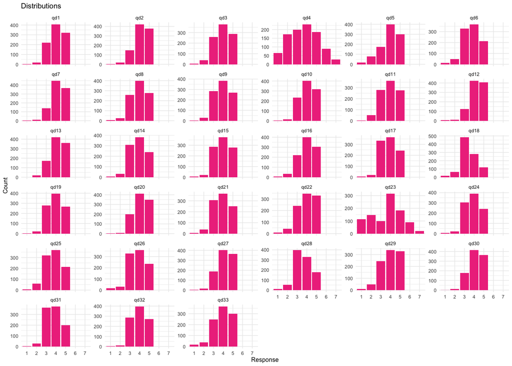

```r
# Convert responses to ordered factor
data_long$Response <- factor(data_long$Response, levels = sort(unique(unlist(Data_clean)))) # Convert all numeric responses into an ordered factor to preserve Likert scale order in plots

# Plot response distributions for all items (directly in R Markdown)
ggplot(data_long, aes(x = Response)) + # Set x-axis to response values
  geom_bar(fill = "violetred2") + # Create bar charts
  facet_wrap(~ Item, scales = "free_y") + # One plot per item
  labs(title = "Distributions", x = "Response", y = "Count") + # Title and axis labels
  theme_minimal(base_size = 6)  # Clean theme
```

## 2.5 **Correlation Matrix**

**Correlation Matrix** The correlation matrix shows how strongly each of the 33 quality-related survey items is **linearly** related to the others. It helps identify clusters of items that may measure the same underlying dimension of perceived quality, serving as a foundation for factor analysis

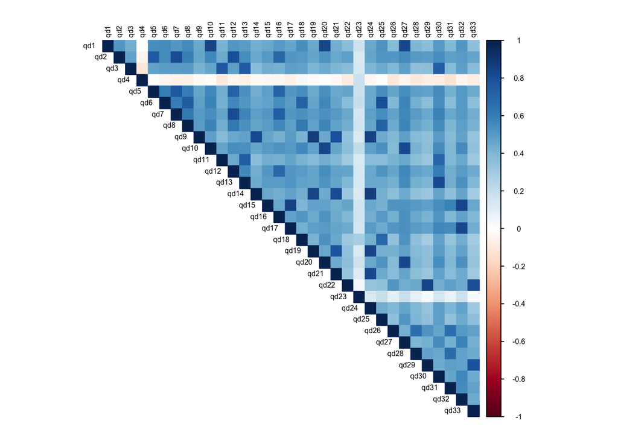

During the inspection of the correlation matrix, we observed an extremely week correlation between **Item 23 (qd23)** and **Item 4 (qd4)**. Such week multicollinearity indicates that these items are not likely measuring the same underlying concept, potentially distorting the factor structure.

## 2.6 **Bartlett’s Test и KMO**

```
##  Bartlett's Test of Sphericity
##
## Call: bart_spher(x = Data_clean[, paste0("qd", 1:33)])
##
##      X2 = 30857.911
##      df = 528
## p-value < 2.22e-16
```

```
## [1] 0.961722
```

```
##       qd4      qd23      qd22      qd29      qd15      qd33      qd17      qd11
## 0.6422860 0.9025359 0.9273572 0.9348269 0.9463654 0.9502085 0.9526272 0.9553342
##      qd25       qd6       qd3      qd24      qd31      qd19      qd13      qd14
## 0.9554307 0.9562057 0.9570940 0.9572029 0.9595275 0.9596475 0.9604076 0.9606687
##       qd1       qd9      qd28      qd32      qd30      qd26      qd20      qd27
## 0.9611377 0.9614243 0.9620148 0.9632269 0.9651743 0.9658695 0.9660218 0.9662994
##       qd2      qd12      qd18      qd10       qd7      qd21       qd5       qd8
## 0.9665563 0.9692788 0.9694107 0.9700651 0.9700763 0.9745578 0.9794715 0.9809143
##      qd16
## 0.9818514
```

**Bartlett’s Test of Sphericity** checks if the correlation matrix is an identity matrix (no relationships between variables). A significant result (p < 0.05) means the variables do have meaningful correlations, which supports using factor analysis or PCA.

**Anti-Image Correlations.** Although qd4 still meet the minimum threshold (above 0.50), its anti-image correlation values are relatively lower compared to the rest. However, qd23 despite a weak visual correlation pattern, shows **good MSA** (0.90).

Since we observed controversial results for qd4 and especially for qd23—with a strong MSA but weak visual correlationit is important to assess its communality to determine how well it is represented by the factor solution.

|  | sort.PC.communality. |
| --- | --- |
| qd4 | 0.004614956 |
| qd23 | 0.046471227 |
| qd33 | 0.358389660 |
| qd22 | 0.382651935 |
| qd29 | 0.388363132 |
| qd31 | 0.409731690 |
| qd11 | 0.412322547 |
| qd28 | 0.412922440 |
| qd26 | 0.419761098 |
| qd3 | 0.459924574 |

[output cut: 23 more lines]

**Communality** measures how much of a variable’s variance is explained by the extracted factors. Values closer to 1 indicate a good fit, while low values suggest the item is not well captured by the model.

In this case, qd23 has a communality of only 0.046, indicating that less than 5% of its variance is accounted for by the factors. qd4 performs even worse, with a communality of just 0.004.

**Conclusion:** qd4 qd23 have low communality, confirming that it does not contribute meaningfully to the factor structure. Therefore, both qd4 and qd23 should be excluded from the final analysis to improve the overall model quality.

## 2.7 **Scree Plot**

```
##  [1] 15.8598680  2.3217762  2.0258331  1.4781631  1.3712708  1.1343846
##  [7]  1.0135713  0.8689483  0.4176516  0.3618149  0.3511069  0.2984164
## [13]  0.2897893  0.2773548  0.2574651  0.2371933  0.2283675  0.2159573
## [19]  0.2020993  0.1931866  0.1811551  0.1692323  0.1641484  0.1556840
## [25]  0.1522619  0.1469643  0.1389878  0.1348376  0.1291215  0.1158191
## [31]  0.1075695
```

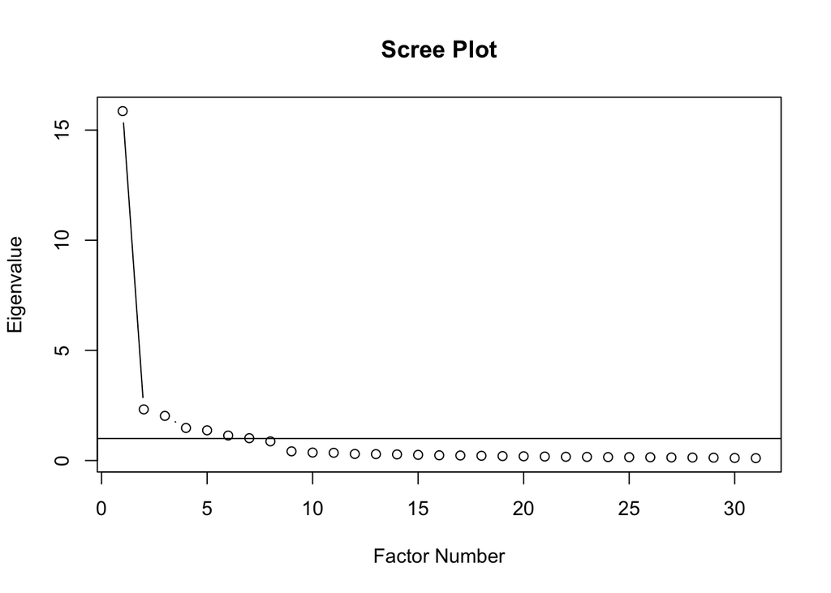

|  | sort.PC0.communality. |
| --- | --- |
| qd33 | 0.3599180 |
| qd22 | 0.3840009 |
| qd29 | 0.3899732 |
| qd31 | 0.4105016 |
| qd11 | 0.4120138 |
| qd28 | 0.4136152 |
| qd26 | 0.4202458 |
| qd3 | 0.4594150 |
| qd18 | 0.4619668 |
| qd14 | 0.4747197 |

[output cut: 21 more lines]

## 2.8 **Principal Component Analysis with Varimax Rotation**

Based on the scree plot and initial inspection of eigenvalues, a solution with **8** factors seems appropriate. To further explore the structure of the data and validate this assumption, a **Principal Component Analysis (PCA)** with **Varimax rotation** will now be conducted.

|  | sort.PCA1.communality. |
| --- | --- |
| qd16 | 0.7281547 |
| qd18 | 0.7417442 |
| qd8 | 0.7445806 |
| qd26 | 0.7696596 |
| qd5 | 0.7781026 |
| qd31 | 0.7916366 |
| qd28 | 0.8042188 |
| qd30 | 0.8142034 |
| qd11 | 0.8172090 |
| qd12 | 0.8230745 |

[output cut: 21 more lines]

Communalities from the PCA with Varimax rotation showed that items were well explained by the retained 8-factor solution. Variables had high communalities ( > 0.70), indicating strong representation in the factor structure.

```
##       EigenValue   Variance Total_Variance
##  [1,] 15.8598680 51.1608646       51.16086
##  [2,]  2.3217762  7.4896008       58.65047
##  [3,]  2.0258331  6.5349453       65.18541
##  [4,]  1.4781631  4.7682680       69.95368
##  [5,]  1.3712708  4.4234540       74.37713
##  [6,]  1.1343846  3.6593051       78.03644
##  [7,]  1.0135713  3.2695850       81.30602
##  [8,]  0.8689483  2.8030591       84.10908
##  [9,]  0.4176516  1.3472632       85.45635
## [10,]  0.3618149  1.1671450       86.62349
## [11,]  0.3511069  1.1326029       87.75609
## [12,]  0.2984164  0.9626335       88.71873
## [13,]  0.2897893  0.9348042       89.65353
## [14,]  0.2773548  0.8946931       90.54822
```

[output cut: 17 more lines]

A Principal Component Analysis (PCA) was conducted on 31 survey items. The first component explained 51.16% of the total variance, indicating a dominant underlying dimension. The first eight components together accounted for 84.11% of the total variance, supporting the adequacy of an 8-factor solution. The remaining components contributed minimally and were not retained for further interpretation. This level of explained variance suggests that the factor model provides a robust and meaningful reduction of the original variable set.

```
##
## Loadings:
##      RC2   RC1   RC5   RC4   RC7   RC6   RC3   RC8
## qd9  0.847
## qd14 0.868
## qd19 0.851
## qd21 0.823
## qd24 0.869
## qd2        0.754
## qd5        0.704
## qd7        0.758
## qd12       0.750
## qd16       0.708
## qd1              0.822
## qd10             0.778
## qd20             0.803
## qd27             0.774
## qd3                    0.807
## qd11                   0.819
## qd13                   0.763
## qd30                   0.706
## qd6                          0.762
## qd8        0.339             0.626
## qd18                         0.715
## qd25                         0.806
## qd22                               0.854
## qd29                               0.841
## qd33                               0.842
## qd15                                     0.787
## qd17                                     0.780
## qd32                                     0.765
## qd26                                           0.727
## qd28                                           0.773
## qd31                                           0.738
##
##                  RC2   RC1   RC5   RC4   RC7   RC6   RC3   RC8
## SS loadings    4.673 3.908 3.492 3.297 3.020 2.856 2.492 2.337
## Proportion Var 0.151 0.126 0.113 0.106 0.097 0.092 0.080 0.075
## Cumulative Var 0.151 0.277 0.389 0.496 0.593 0.685 0.766 0.841
```

Each factor groups together items with high loadings, reflecting distinct psychological or product-related dimensions. Factor names were assigned based on the thematic content of the items with the strongest loadings.

Table: Factors and Their Interpretations Based on PCA (Varimax) Loadings

[output not shown]

## 2.9 **Principal Axis Factoring (PAF) with Varimax rotation**

|  | sort.PAF1.communality. |
| --- | --- |
| qd18 | 0.6266777 |
| qd16 | 0.6402010 |
| qd26 | 0.6551763 |
| qd28 | 0.6849299 |
| qd8 | 0.6855023 |
| qd31 | 0.7001560 |
| qd11 | 0.7169741 |
| qd5 | 0.7224583 |
| qd33 | 0.7612886 |
| qd3 | 0.7629531 |

[output cut: 21 more lines]

The communalities obtained from the Principal Axis Factoring (PAF) model indicate how well each survey item is explained by the extracted factors. In this analysis, the majority of items showed moderate to high communalities, with values starting from 0.63. These values suggest that these items share substantial common variance with other items and are well represented within the factor structure.

```
##       EigenValue_PAF1 Variance_PAF1 Total_Variance_PAF1
##  [1,]      15.8598680    51.1608646            51.16086
##  [2,]       2.3217762     7.4896008            58.65047
##  [3,]       2.0258331     6.5349453            65.18541
##  [4,]       1.4781631     4.7682680            69.95368
##  [5,]       1.3712708     4.4234540            74.37713
##  [6,]       1.1343846     3.6593051            78.03644
##  [7,]       1.0135713     3.2695850            81.30602
##  [8,]       0.8689483     2.8030591            84.10908
##  [9,]       0.4176516     1.3472632            85.45635
## [10,]       0.3618149     1.1671450            86.62349
## [11,]       0.3511069     1.1326029            87.75609
## [12,]       0.2984164     0.9626335            88.71873
## [13,]       0.2897893     0.9348042            89.65353
## [14,]       0.2773548     0.8946931            90.54822
```

[output cut: 17 more lines]

```
##
## Loadings:
##      PA2   PA1   PA5   PA4   PA3   PA7   PA6   PA8
## qd9  0.827
## qd14 0.851
## qd19 0.832
## qd21 0.785
## qd24 0.860
## qd2        0.723
## qd5        0.645
## qd7        0.738
## qd12       0.711
## qd16       0.616
## qd1              0.797
## qd10             0.749
## qd20             0.772
## qd27             0.747
## qd3                    0.759
## qd11                   0.749
## qd13                   0.739
## qd30                   0.677
## qd22                         0.837
## qd29                         0.813
## qd33                         0.780
## qd6                                0.741
## qd8        0.341                   0.558
## qd18                               0.601
## qd25                               0.762
## qd15                                     0.749
## qd17                                     0.744
## qd32                                     0.715
## qd26                                           0.620
## qd28                                           0.672
## qd31                                           0.660
##
##                  PA2   PA1   PA5   PA4   PA3   PA7   PA6   PA8
## SS loadings    4.569 3.577 3.404 3.121 2.781 2.675 2.324 1.935
## Proportion Var 0.147 0.115 0.110 0.101 0.090 0.086 0.075 0.062
## Cumulative Var 0.147 0.263 0.373 0.473 0.563 0.649 0.724 0.787
```

Each factor was defined by items with strong loadings (≥ 0.30), with minimal cross-loading. Key groupings—such as qd9, qd14, qd19, and qd24 on PA2, and qd2, qd5, qd7, and qd12 on PA1—reflected consistent themes like serviceability and style consciousness.

Table: Factors and Their Interpretations Based on PAF (Varimax) Loadings

[output not shown]

## 2.10 **PCA and PAF comparison**

Side-by-Side Comparison of PCA and PAF (Varimax)

| Factor | Eigen_PCA | Eigen_PAF | Variance_PCA | Variance_PAF | Cumulative_PCA | Cumulative_PAF |
| --- | --- | --- | --- | --- | --- | --- |
| 1 | 15.860 | 15.860 | 51.16 | 51.16 | 51.16 | 51.16 |
| 2 | 2.322 | 2.322 | 7.49 | 7.49 | 58.65 | 58.65 |
| 3 | 2.026 | 2.026 | 6.53 | 6.53 | 65.19 | 65.19 |
| 4 | 1.478 | 1.478 | 4.77 | 4.77 | 69.95 | 69.95 |
| 5 | 1.371 | 1.371 | 4.42 | 4.42 | 74.38 | 74.38 |
| 6 | 1.134 | 1.134 | 3.66 | 3.66 | 78.04 | 78.04 |
| 7 | 1.014 | 1.014 | 3.27 | 3.27 | 81.31 | 81.31 |
| 8 | 0.869 | 0.869 | 2.80 | 2.80 | 84.11 | 84.11 |
| 9 | 0.418 | 0.418 | 1.35 | 1.35 | 85.46 | 85.46 |
| 10 | 0.362 | 0.362 | 1.17 | 1.17 | 86.62 | 86.62 |
| 11 | 0.351 | 0.351 | 1.13 | 1.13 | 87.76 | 87.76 |
| 12 | 0.298 | 0.298 | 0.96 | 0.96 | 88.72 | 88.72 |
| 13 | 0.290 | 0.290 | 0.93 | 0.93 | 89.65 | 89.65 |
| 14 | 0.277 | 0.277 | 0.89 | 0.89 | 90.55 | 90.55 |
| 15 | 0.257 | 0.257 | 0.83 | 0.83 | 91.38 | 91.38 |
| 16 | 0.237 | 0.237 | 0.77 | 0.77 | 92.14 | 92.14 |
| 17 | 0.228 | 0.228 | 0.74 | 0.74 | 92.88 | 92.88 |
| 18 | 0.216 | 0.216 | 0.70 | 0.70 | 93.58 | 93.58 |
| 19 | 0.202 | 0.202 | 0.65 | 0.65 | 94.23 | 94.23 |
| 20 | 0.193 | 0.193 | 0.62 | 0.62 | 94.85 | 94.85 |
| 21 | 0.181 | 0.181 | 0.58 | 0.58 | 95.44 | 95.44 |
| 22 | 0.169 | 0.169 | 0.55 | 0.55 | 95.98 | 95.98 |
| 23 | 0.164 | 0.164 | 0.53 | 0.53 | 96.51 | 96.51 |
| 24 | 0.156 | 0.156 | 0.50 | 0.50 | 97.01 | 97.01 |
| 25 | 0.152 | 0.152 | 0.49 | 0.49 | 97.51 | 97.51 |
| 26 | 0.147 | 0.147 | 0.47 | 0.47 | 97.98 | 97.98 |
| 27 | 0.139 | 0.139 | 0.45 | 0.45 | 98.43 | 98.43 |
| 28 | 0.135 | 0.135 | 0.43 | 0.43 | 98.86 | 98.86 |
| 29 | 0.129 | 0.129 | 0.42 | 0.42 | 99.28 | 99.28 |
| 30 | 0.116 | 0.116 | 0.37 | 0.37 | 99.65 | 99.65 |
| 31 | 0.108 | 0.108 | 0.35 | 0.35 | 100.00 | 100.00 |

The table shows a nearly identical pattern of eigenvalues and explained variance between PCA and PAF for the first 20 factors. Both methods yield the same eigenvalues and cumulative variance up to Factor 8, reaching 84.11% of total variance explained.

Side-by-Side Comparison of Factor Metrics from PCA and PAF (Varimax)

| Metric | RC2..PCA. | PA2..PAF. | RC1..PCA. | PA1..PAF. | RC5..PCA. | PA5..PAF. | RC4..PCA. | PA4..PAF. | RC7..PCA. | PA3..PAF. | RC6..PCA. | PA7..PAF. | RC3..PCA. | PA6..PAF. | RC8..PCA. | PA8..PAF. |
| --- | --- | --- | --- | --- | --- | --- | --- | --- | --- | --- | --- | --- | --- | --- | --- | --- |
| SS Loadings | 4.673 | 4.569 | 3.908 | 3.577 | 3.492 | 3.404 | 3.297 | 3.121 | 3.020 | 2.781 | 2.856 | 2.675 | 2.492 | 2.324 | 2.337 | 1.935 |
| Proportion of Variance | 0.151 | 0.147 | 0.126 | 0.115 | 0.113 | 0.110 | 0.106 | 0.101 | 0.097 | 0.090 | 0.092 | 0.086 | 0.080 | 0.075 | 0.075 | 0.062 |
| Cumulative Variance | 0.151 | 0.147 | 0.277 | 0.263 | 0.389 | 0.373 | 0.496 | 0.473 | 0.593 | 0.563 | 0.685 | 0.649 | 0.766 | 0.724 | 0.841 | 0.787 |

The comparison shows very similar SS loadings, proportion of variance, and cumulative variance for each factor across PCA and PAF. While PCA slightly overestimates the variance explained (as it includes unique variance), PAF presents a more conservative estimate by focusing on shared variance only. Despite this, the difference is minimal. This further supports the robustness of the 8-factor structure.